# STP598sta: Spatiotemporal Analysis

State Space Models

Shiwei Lan

Fall 2021

In lecture 9, we have introduced state space models. We will discuss some examples in this demo. We will particularly use the `R` package `astsa`.

```r
install.packages('astsa')
```

```r
library(astsa)
library(xts)
set.seed(2020)
```

## Introduction to State Space Models

### Prediction-Filter-Smoother

In lecture 9 we discussed obtaining the state $x_t$ based on the observed data $y_{1:s}$ up to time $s$ and introduced the concepts of `smoothing` ($t<s$), `filtering` $t=s$ and `forecasting or prediction` ($t>s$). We derived Kalman filter for the linear Gaussian model.

Let’s first construct a simple example of linear Gaussian model.
$$\begin{align}
x_{t} &= x_{t-1} + w_{t}, \quad w_t \overset{iid}N(0,1) \\
y_{t} &= x_t + v_t{t}, \quad v_t \overset{iid}N(0,1)
\end{align}$$

```r
# generate data
set.seed(1)
num = 50
w = rnorm(num+1,0,1)
v = rnorm(num,0,1)

mu = cumsum(w)  # states:  mu[0], mu[1], . . ., mu[50]
y = mu[-1] + v  # obs:  y[1], . . ., y[50]
```

Then we use Kalman filter (`Ksmooth0` function) to obtain prediction $x_t^{t-1}$ (`xp`), filter $x_t^t$ (`xf`) and smooth $x_t^n$ (`xs`) respectively.

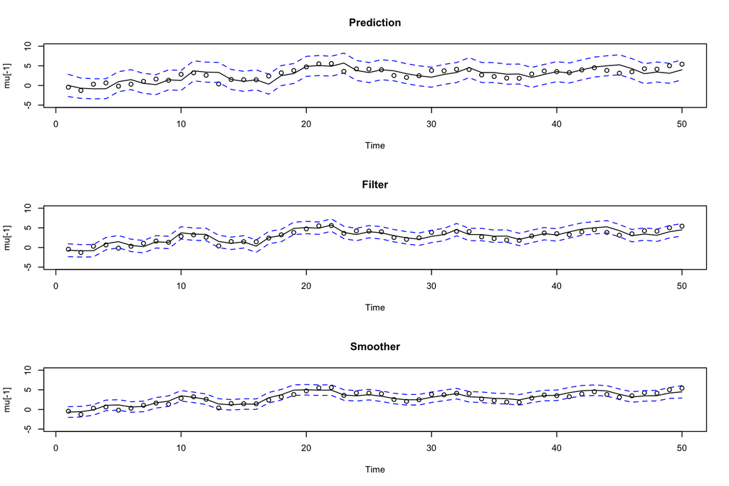

```r
# filter and smooth (Ksmooth0 does both)
mu0 = 0; sigma0 = 1;  phi = 1; cQ = 1; cR = 1
ks = Ksmooth0(num, y, 1, mu0, sigma0, phi, cQ, cR)

# pictures
par(mfrow=c(3,1))
Time = 1:num

plot(Time, mu[-1], main="Prediction", ylim=c(-5,10))
  lines(ks$xp)
  lines(ks$xp+2*sqrt(ks$Pp), lty="dashed", col="blue")
  lines(ks$xp-2*sqrt(ks$Pp), lty="dashed", col="blue")

plot(Time, mu[-1], main="Filter", ylim=c(-5,10))
  lines(ks$xf)
  lines(ks$xf+2*sqrt(ks$Pf), lty="dashed", col="blue")
  lines(ks$xf-2*sqrt(ks$Pf), lty="dashed", col="blue")

plot(Time, mu[-1],  main="Smoother", ylim=c(-5,10))
  lines(ks$xs)
  lines(ks$xs+2*sqrt(ks$Ps), lty="dashed", col="blue")
  lines(ks$xs-2*sqrt(ks$Ps), lty="dashed", col="blue")
```

We can observe the error bounds becoming narrower as it transitions from `prediction` to `smoother`. We can also contrast the results by plotting them on the same graph.

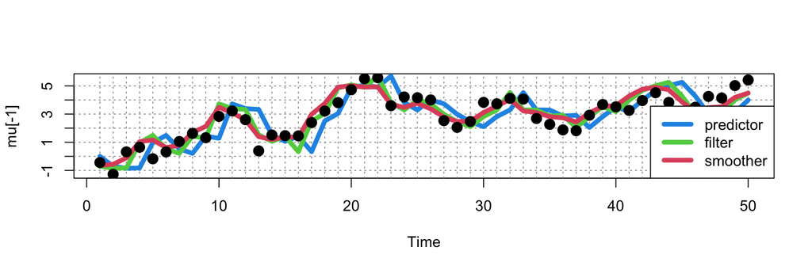

```r
plot(Time, mu[-1], type='n')
abline(v=Time, lty=3, col=8)
abline(h=-1:5, lty=3, col=8)
lines(ks$xp, col=4, lwd=5)
lines(ks$xf, col=3, lwd=5)
lines(ks$xs, col=2, lwd=5)
points(Time, mu[-1], pch=19, cex=1.5)
names = c("predictor","filter","smoother")
legend("bottomright", names, col=4:2, lwd=5, lty=1, bg="white")
```

### Maximum Likelihood Estimation

Now we switch to estimating the parameters of the state space model using maximum likelihood estimation (MLE).

Consider the state space model and geneate the simulated data.
$$\begin{align}
y_t &= x_t + v_t, \quad v_t \overset{iid}{\sim} N(0, \sigma^2_v) \\
x_t &= \phi x_{t-1} + w_t, \quad w_t \overset{iid}{\sim} N(0, \sigma^2_w) \\
\end{align}$$

```r
# Generate Data
set.seed(999)
num = 100
N = num+1
x = arima.sim(n=N, list(ar = .8, sd=1))
y = ts(x[-1] + rnorm(num,0,1))
```

Then we initialize parameters using what we calculated before
$$\begin{equation}
\phi^{(0)} = \frac{\hat\rho_y(2)}{\hat\rho_y(1)}, \quad
(\sigma^2_w)^{(0)} = \frac{1-(\phi^{(0)})^2}{\phi^{(0)}} \hat\gamma_y(1), \quad
(\sigma^2_v)^{(0)} = \hat\gamma_y(0) - \frac{(\sigma^2_w)^{(0)}}{1-(\phi^{(0)})^2}
\end{equation}$$

```r
# Initial Estimates
u = ts.intersect(y, lag(y,-1), lag(y,-2))
varu = var(u)
coru = cor(u)
phi = coru[1,3]/coru[1,2]
q = (1-phi^2)*varu[1,2]/phi
r = varu[1,1] - q/(1-phi^2)
(init.par = c(phi, sqrt(q), sqrt(r)))
```

```
## [1] 0.9087024 0.5107053 1.0291205
```

Lastly, we use `BFGS`to optimize the log-likelihood function to obtain MLE estimate.

```r
# Function to evaluate the likelihood
Linn=function(para){
  phi = para[1]; sigw = para[2]; sigv = para[3]
  Sigma0 = (sigw^2)/(1-phi^2); Sigma0[Sigma0<0]=0
  kf = Kfilter0(num,y,1,mu0=0,Sigma0,phi,sigw,sigv)
  return(kf$like)
}

# Estimation
(est = optim(init.par, Linn, gr=NULL, method="BFGS", hessian=TRUE, control=list(trace=1,REPORT=1)))
```

```
## $par
## [1] 0.8137623 0.8507863 0.8743968
##
## $value
## [1] 79.01445
##
## $counts
## function gradient
##       23        7
##
## $convergence
## [1] 0
##
## $message
## NULL
##
## $hessian
##           [,1]     [,2]     [,3]
## [1,] 253.36290 67.39775 -9.64101
## [2,]  67.39775 78.99067 48.61052
## [3,]  -9.64101 48.61052 92.20472
```

```r
SE = sqrt(diag(solve(est$hessian)))
cbind(estimate=c(phi=est$par[1],sigw=est$par[2],sigv=est$par[3]), SE)
```

```
##       estimate         SE
## phi  0.8137623 0.08060636
## sigw 0.8507863 0.17528895
## sigv 0.8743968 0.14293192
```

### Hidden Markov Models (HMM)

Now we consider a Poisson-HMM model for the number of major earthquakes, $y_t$, with data in `depmixS4` library.
$$\begin{align}
P[x_t=1] &\pi_1=\frac{\pi_{21}}{\pi_{12}+\pi_{21}}, \quad P[x_t=2]=\pi_2=\frac{\pi_{12}}{\pi_{12}+\pi_{21}} \\
P[y_{t}|x_t=i] &= p_j(y) = \frac{\lambda_j^y e^{-\lambda_j}}{y!}, \quad y=1,2,\cdots
\end{align}$$

```r
library(depmixS4)
##  note - as of updata 1.4-2, you can get standard errors ##
model <- depmix(EQcount ~1, nstates=2, data=data.frame(EQcount), family=poisson('identity'), respstart=c(15,25))
set.seed(90210)
summary(fm <- fit(model))   # estimation results
```

```
## converged at iteration 26 with logLik: -341.8787
## Initial state probabilities model
## pr1 pr2
##   1   0
##
## Transition matrix
##         toS1  toS2
## fromS1 0.928 0.072
## fromS2 0.119 0.881
##
## Response parameters
## Resp 1 : poisson
##     Re1.(Intercept)
## St1          15.419
## St2          26.014
```

```r
standardError(fm)           # with standard errors
```

```
##           par constr         se
## 1  1.00000000    bnd         NA
## 2  0.00000000    bnd         NA
## 3  0.92834885    inc 0.03763795
## 4  0.07165115    inc 0.03763795
## 5  0.11895483    inc 0.06359283
## 6  0.88104517    inc 0.06359283
## 7 15.41900953    inc 0.71750932
## 8 26.01445316    inc 1.38270091
```

```r
##-- Get + Display Parameters --##
para.mle = as.vector(getpars(fm))[3:8]
( mtrans = matrix(para.mle[1:4], byrow=TRUE, nrow=2) )
```

```
##           [,1]       [,2]
## [1,] 0.9283489 0.07165115
## [2,] 0.1189548 0.88104517
```

```r
( lams   = para.mle[5:6] )
```

```
## [1] 15.41901 26.01445
```

```r
( pi1    = mtrans[2,1]/(2 - mtrans[1,1] - mtrans[2,2]) )
```

```
## [1] 0.6240876
```

```r
( pi2    = 1 - pi1 )
```

```
## [1] 0.3759124
```

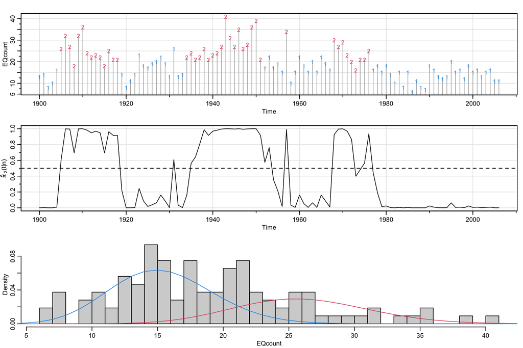

```r
#-- Graphics --##
par(mfrow=c(3,1))
# data and states
tsplot(EQcount, main="", ylab='EQcount', type='h', col=gray(.7))
text(EQcount, col=6*posterior(fm)[,1]-2, labels=posterior(fm)[,1], cex=.9)
# prob of state 2
tsplot(ts(posterior(fm)[,3], start=1900), ylab = expression(hat(pi)[~2]*'(t|n)'));  abline(h=.5, lty=2)
# histogram
hist(EQcount, breaks=30, prob=TRUE, main="")
xvals = seq(1,45)
u1 = pi1*dpois(xvals, lams[1])
u2 = pi2*dpois(xvals, lams[2])
lines(xvals, u1, col=4)
lines(xvals, u2, col=2)
```

## Bayesian State Space Models

Lastly, we consider a Bayesian analysis of the above local level model
$$\begin{equation}
\begin{aligned}
y_t &= \mu_t + v_t, \quad v_t \overset{iid}{\sim} N(0, \sigma^2_v) \\
\mu_t &= \mu_{t-1} + w_t, \quad w_t \overset{iid}{\sim} N(0, \sigma^2_w) \\
\end{aligned}
\end{equation}$$
We generate $y_{1:n}$ for $n=100$ with true values $\sigma^2_w = 0.5$ and $\sigma^2_v =1$.

```r
# Simulate states and data
set.seed(1); W = 0.5; V = 1.0
n  = 100; m0 = 0.0; C0 = 10.0; x0 = 0
w  = rnorm(n,0,sqrt(W))
v  = rnorm(n,0,sqrt(V))
x  = y = rep(0,n)
x[1] = x0   + w[1]
y[1] = x[1] + v[1]
for (t in 2:n){
  x[t] = x[t-1] + w[t]
  y[t] = x[t] + v[t]   }
```

Then We adopt inverse gamma priors for variance parameters
$$\begin{equation}
\sigma^2_w \sim \Gamma^{-1}(a_0/2, b_0/2), \quad \sigma^2_v \sim \Gamma^{-1}(c_0/2, d_0/2)
\end{equation}$$
where we set $a_0=b_0=c_0=d_0=0.02$. We use forward-filtering, backward- sampling (FFBS) algorithm to obtain the samples of the state. We run MCMC to obtain 1010 samples and burn in the first 10.

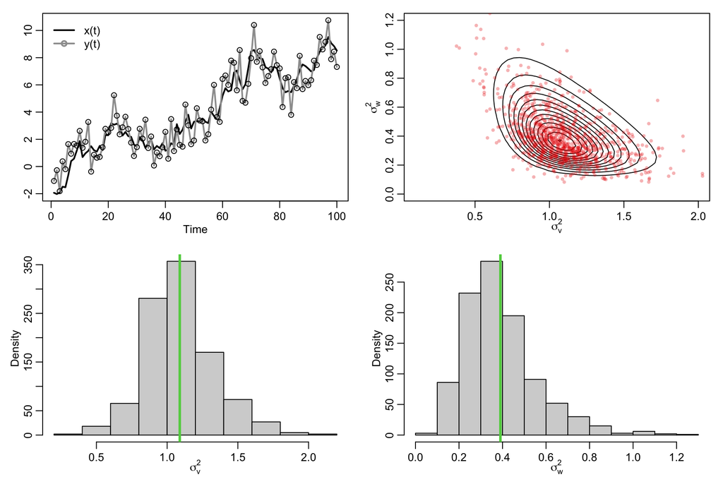

```r
#########################################################################################
# Adapted from code by: Hedibert Freitas Lopes
#########################################################################################
##-- Notation --##
#           y(t) = x(t) + v(t);    v(t) ~ iid N(0,V)
#           x(t) = x(t-1) + w(t);  w(t) ~ iid N(0,W)
#  priors:  x(0) ~ N(m0,C0);  V ~ IG(a,b);  W ~ IG(c,d)
#    FFBS:  x(t|t) ~ N(m,C);  x(t|n) ~ N(mm,CC);  x(t|t+1) ~ N(a,R)
##--
ffbs = function(y,V,W,m0,C0){
  n  = length(y);  a  = rep(0,n);  R  = rep(0,n)
  m  = rep(0,n);   C  = rep(0,n);  B  = rep(0,n-1)
  H  = rep(0,n-1); mm = rep(0,n);  CC = rep(0,n)
  x  = rep(0,n); llike = 0.0
  for (t in 1:n){
    if(t==1){a[1] = m0; R[1] = C0 + W
    }else{ a[t] = m[t-1]; R[t] = C[t-1] + W }
    f      = a[t]
    Q      = R[t] + V
    A      = R[t]/Q
    m[t]   = a[t]+A*(y[t]-f)
    C[t]   = R[t]-Q*A**2
    B[t-1] = C[t-1]/R[t]
    H[t-1] = C[t-1]-R[t]*B[t-1]**2
    llike  = llike + dnorm(y[t],f,sqrt(Q),log=TRUE) }
  mm[n] = m[n]; CC[n] = C[n]
  x[n]  = rnorm(1,m[n],sqrt(C[n]))
  for (t in (n-1):1){
    mm[t] = m[t] + C[t]/R[t+1]*(mm[t+1]-a[t+1])
    CC[t] = C[t] - (C[t]^2)/(R[t+1]^2)*(R[t+1]-CC[t+1])
    x[t]  = rnorm(1,m[t]+B[t]*(x[t+1]-a[t+1]),sqrt(H[t]))  }
  return(list(x=x,m=m,C=C,mm=mm,CC=CC,llike=llike))   }

# actual smoother (for plotting)
ks = Ksmooth0(num=n, y, A=1, m0, C0, Phi=1, cQ=sqrt(W), cR=sqrt(V))
xsmooth = as.vector(ks$xs)
#
run = ffbs(y,V,W,m0,C0)
m   = run$m; C = run$C; mm = run$mm
CC  = run$CC; L1 = m-2*C; U1  = m+2*C
L2  = mm-2*CC; U2 = mm+2*CC
N   = 50
Vs  = seq(0.1,2,length=N)
Ws  = seq(0.1,2,length=N)
likes = matrix(0,N,N)
for (i in 1:N){
  for (j in 1:N){
    V   = Vs[i]
    W   = Ws[j]
    run = ffbs(y,V,W,m0,C0)
    likes[i,j] = run$llike  }  }
# Hyperparameters
a = 0.01; b = 0.01; c = 0.01; d = 0.01
# MCMC step
set.seed(90210)
burn  = 10;  M = 1000
niter = burn + M
V1    = V;  W1 = W
draws = NULL
all_draws = NULL
for (iter in 1:niter){
  run   = ffbs(y,V1,W1,m0,C0)
  x     = run$x
  V1    = 1/rgamma(1,a+n/2,b+sum((y-x)^2)/2)
  W1    = 1/rgamma(1,c+(n-1)/2,d+sum(diff(x)^2)/2)
  draws = rbind(draws,c(V1,W1,x))    }
all_draws = draws[,1:2]
q025  = function(x){quantile(x,0.025)}
q975  = function(x){quantile(x,0.975)}
draws = draws[(burn+1):(niter),]
xs    = draws[,3:(n+2)]
lx    = apply(xs,2,q025)
mx    = apply(xs,2,mean)
ux    = apply(xs,2,q975)
##  plot of the data
par(mfrow=c(2,2), mgp=c(1.6,.6,0), mar=c(3,3.2,1,1))
ts.plot(ts(x), ts(y), ylab='', col=c(1,8), lwd=2)
points(y)
legend(0, 11, legend=c("x(t)","y(t)"), lty=1, col=c(1,8), lwd=2, bty="n", pch=c(-1,1))
contour(Vs, Ws, exp(likes), xlab=expression(sigma[v]^2), ylab=expression(sigma[w]^2),
        drawlabels=FALSE, ylim=c(0,1.2))
points(draws[,1:2], pch=16, col=rgb(.9,0,0,0.3), cex=.7)
hist(draws[,1], ylab="Density",main="", xlab=expression(sigma[v]^2))
abline(v=mean(draws[,1]), col=3, lwd=3)
hist(draws[,2],main="", ylab="Density", xlab=expression(sigma[w]^2))
abline(v=mean(draws[,2]), col=3, lwd=3)
```

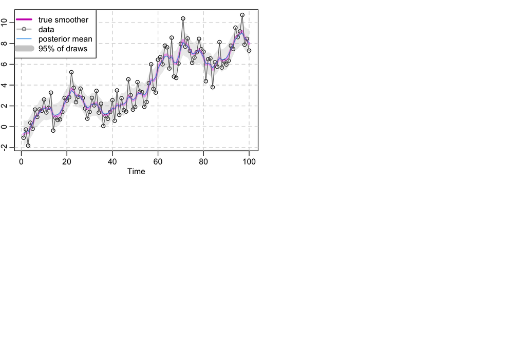

```r
## plot states
par(mgp=c(1.6,.6,0), mar=c(2,1,.5,0)+.5)
plot(ts(mx), ylab='', type='n', ylim=c(min(y),max(y)))
grid(lty=2); points(y)
lines(xsmooth, lwd=4, col=rgb(1,0,1,alpha=.4))
lines(mx, col= 4)
xx=c(1:100, 100:1)
yy=c(lx, rev(ux))
polygon(xx, yy, border=NA, col= gray(.6,alpha=.2))
lines(y, col=gray(.4))
legend('topleft', c('true smoother', 'data', 'posterior mean', '95% of draws'), lty=1,
       lwd=c(3,1,1,10), pch=c(-1,1,-1,-1), col=c(6, gray(.4), 4, gray(.6, alpha=.5)),
       bg='white' )
```